# Project 2: Dijkstra’s Algorithm

Har Jing Daryl

Goh Teng Wei

Koh Jun Kai

# Time Complexity of Dijkstra's Algorithm

We assume that we are working on a graph G = (V, E).

Analysing the algorithm provides us with a few points of interest when analysing the time complexity:

```
1.Looping through each vertex at least once for the outer for-loop.
2.Implementation of the priority queue (arguably the most important!).
3.Looping through each vertex's neighbours.
```

# Part a) Adjacency Matrix

For the first part, the algorithm is implemented using an `adjacency matrix` for the graph, and an `array` for the priority queue.

The outer loop is where we loop through each vertex at least once. This takes `O(V)` time.

On each iteration, we call the priority queue to get the next vertex. Since the queue is implemented using an array, the getMinimum function in the queue loops through each vertex once, thus the operation will take `O(V)` time.

Within this outer loop, we also have an inner loop looping through all the current vertex's neighbours. This takes `O(V)` time for an adjacency matrix.

As such, each loop iteration takes `O(V+V)` time.

Therefore, the total time complexity is **O(V(V+V)) ~=O(V<sup>2</sup>)**

# Part b) Adjacency List

For the second part, the algorithm is implemented using an `adjacency list` for the graph, and a `min-heap` for the priority queue.

The first thing we notice is that operations on the heap take `O(logn)` time, where `n` is the number of elements in the heap.

We see that like part a), we have to loop through each vertex at least once for the outer loop. This takes `O(V)` time.

On each iteration, we have to remove a node from the heap, which is a `O(logV)` operation.

Then, we also have to loop through each neighbour of the current vertex.

### What is the time complexity of this inner loop operation?-

Notice that any useful work is done **only on an edge of the graph**. The useful work (which updates the heap with the new weight), is a `O(logV)` operation.

As such, if we count all the number of times the inner loop runs, we will realise that we only do `O(ElogV)`operations in total, regardless of the number of times the outer loop has to run.

Therefore, the total time complexity would be **O(VlogV + ElogV) ~= O((V + E)logV)**.

### Reading results

```python
# Read results
results = pd.read_csv("results.csv")
results
```

|  | type | v | e | time |
| --- | --- | --- | --- | --- |
| 0 | matrix | 2 | 1 | 13151.344444 |
| 1 | list | 2 | 1 | 29459.477778 |
| 2 | matrix | 2 | 2 | 5499.755556 |
| 3 | list | 2 | 2 | 14111.677778 |
| 4 | matrix | 3 | 1 | 3625.044444 |
| ... | ... | ... | ... | ... |
| 328635 | list | 79 | 6160 | 76246.866667 |
| 328636 | matrix | 79 | 6161 | 48764.788889 |
| 328637 | list | 79 | 6161 | 75731.822222 |
| 328638 | matrix | 79 | 6162 | 48954.222222 |
| 328639 | list | 79 | 6162 | 75496.511111 |

328640 rows × 4 columns

# a) Adjacency Matrix with Array as Priority Queue

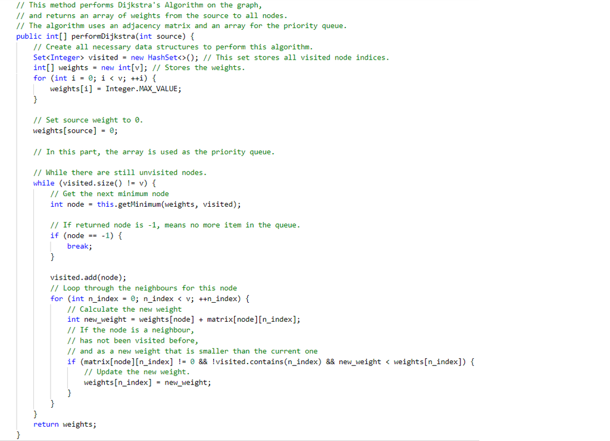

```python
# Get only results for adjacency matrix implementation
res_matrix = results[results.type == "matrix"]
res_matrix
```

|  | type | v | e | time |
| --- | --- | --- | --- | --- |
| 0 | matrix | 2 | 1 | 13151.344444 |
| 2 | matrix | 2 | 2 | 5499.755556 |
| 4 | matrix | 3 | 1 | 3625.044444 |
| 6 | matrix | 3 | 2 | 1869.166667 |
| 8 | matrix | 3 | 3 | 2163.177778 |
| ... | ... | ... | ... | ... |
| 328630 | matrix | 79 | 6158 | 48601.800000 |
| 328632 | matrix | 79 | 6159 | 49570.144444 |
| 328634 | matrix | 79 | 6160 | 49450.422222 |
| 328636 | matrix | 79 | 6161 | 48764.788889 |
| 328638 | matrix | 79 | 6162 | 48954.222222 |

164320 rows × 4 columns

## Varying V, the number of vertices

We also assume that the graphs have the maximum number of edges.

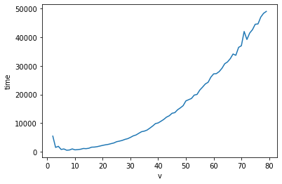

```python
sb.lineplot(data=res_matrix[(res_matrix.e == (res_matrix.v ** 2 - res_matrix.v))], x="v", y="time")
```

From our analysis, we know that this implementation has **O(V<sup>2</sup>)** complexity.

We can clearly see this pattern emerge during empirical analysis as well!

## Varying E, the number of edges

Is there a significant difference in timings from different E values?

To check this, we can plot for different E values for some values of V.

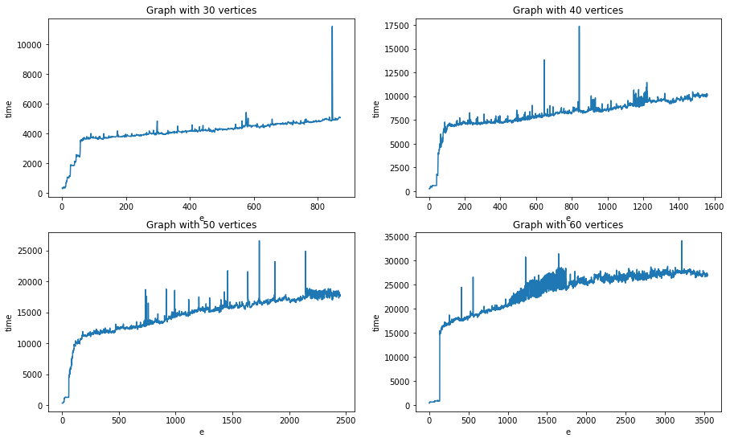

```python
_, axes = plt.subplots(nrows=2, ncols=2,figsize=(15, 9)) # Make 2x2 subplots
v = 30
for row in axes:
    for index, col in enumerate(row):
        sb.lineplot(data=res_matrix[res_matrix.v == v],
                    x="e", y="time", ax=row[index]).set_title(f"Graph with {v} vertices")
        v += 10
```

We can see that the value of E has a **minor** effect on the timings.

In the theoretical analysis, E is not even considered. However, in reality, we can see that as more edges appear in the graph, we do have to do some extra work (setting the new value into the weights array).

# B) Adjacency List with Min-Heap as Priority Queue

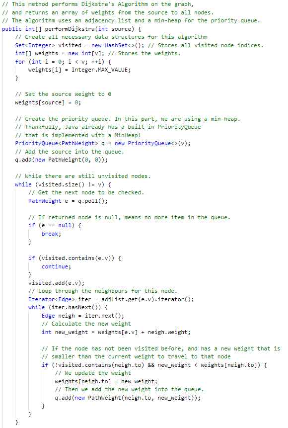

```python
# Get only results for adjacency list
res_list = results[results.type == "list"]
res_list
```

|  | type | v | e | time |
| --- | --- | --- | --- | --- |
| 1 | list | 2 | 1 | 29459.477778 |
| 3 | list | 2 | 2 | 14111.677778 |
| 5 | list | 3 | 1 | 6752.188889 |
| 7 | list | 3 | 2 | 3283.877778 |
| 9 | list | 3 | 3 | 2986.211111 |
| ... | ... | ... | ... | ... |
| 328631 | list | 79 | 6158 | 75602.033333 |
| 328633 | list | 79 | 6159 | 76792.666667 |
| 328635 | list | 79 | 6160 | 76246.866667 |
| 328637 | list | 79 | 6161 | 75731.822222 |
| 328639 | list | 79 | 6162 | 75496.511111 |

164320 rows × 4 columns

## Varying V, the number of vertices

To show variation with V, we use a constant value for E. In this case, we use 1200, which allows for more data points but can still reasonably show a pattern.

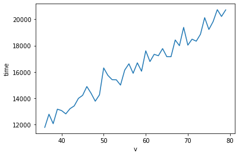

```python
sb.lineplot(data=res_list[res_list.e == 1200], x="v", y="time")
```

## Varying E, the number of edges

To show variation with E, we keep V constant.

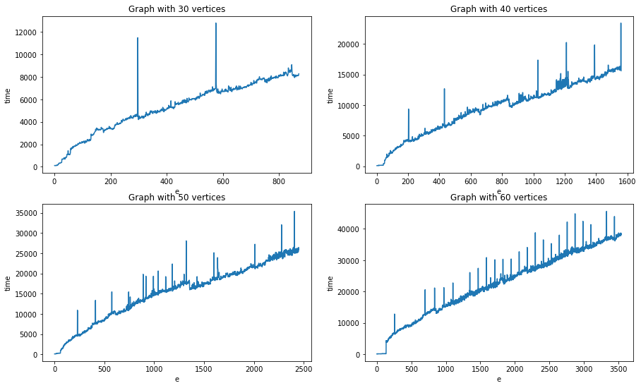

```python
_, axes = plt.subplots(nrows=2, ncols=2,figsize=(15, 9)) # Make 2x2 subplots
v = 30
for row in axes:
    for index, col in enumerate(row):
        sb.lineplot(data=res_list[res_list.v == v],
                    x="e", y="time", ax=row[index]).set_title(f"Graph with {v} vertices")
        v += 10
```

We can see that for any V, as the number of edges, E, increases, the time taken for each graph also increases. This also agrees with our theoretical analysis of the time complexity.

# Conclusion: Which implementation to use?

To show the difference, we plot for certain intervals of V with varying E.

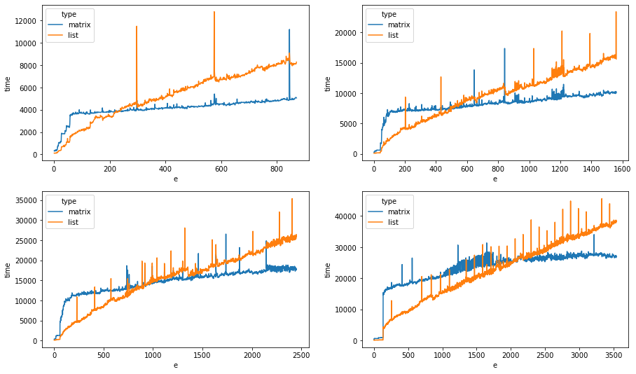

```python
_, axes = plt.subplots(nrows=2, ncols=2, figsize=(15, 9))

sb.lineplot(data=results[results.v == 30], x="e", y="time", hue="type", ax=axes[0][0])
sb.lineplot(data=results[results.v == 40], x="e", y="time", hue="type", ax=axes[0][1])
sb.lineplot(data=results[results.v == 50], x="e", y="time", hue="type", ax=axes[1][0])
sb.lineplot(data=results[results.v == 60], x="e", y="time", hue="type", ax=axes[1][1])
```

We can see that for any V, as the number of edges, E, increases, the `list implementation` will result in **worse results** than just using a `matrix implementation`.

This agress with our theoretical analysis of the time complexity for large values of E.

## Recap: Time Complexities

a) Adjacency Matrix: **`O(V^2)`**

b) Adjacency List: **`O((V + E)logV)`**

### Scenerio 1

Suppose our graph is `close to completion` (each vertex is almost a neighbour of every other vertex), then the complexity for the second implementation would degrade to **O((V + V<sup>2</sup>)logV)**. This is much worse than **O(V<sup>2</sup>)** for the first implementation.

### Scenerio 2

However, if our graph is `sparse` (not many edges), then we can see that the second implementation generally takes a shorter time.

### Conclusion

If the graph is `close to completion`, we would apply the first implementation:  
**Adjacency Matrix with Array as Priority Queue**.

If the graph is `sparse`, we would apply the second implementation:  
**Adjacency List with Min Heap as Priority Queue**.